# DRIP IRRIGATION ADOPTION IN MWEA IRRGATON SCHEME-KENYA.

Adrian, Aparna, Silas, Steven

2023-07-12

# Introduction

Demand for more reliable food sources, continuous depletion of natural resources and climate change due to anthropogenic factors have become a point of concern. It is from this background that many governments around the world set up irrigation schemes to enhance food and nutrition security, and improve livelihoods in rural areas. (Mati (2023))

Kenya has a great potential to increase food production to get liberated from seasonal agricultural dependency through investing in more water efficient agricultural technologies to improve yields and subsequently rural development.(Kanda and Lutta (2022))

Around 80% (Strategic-Plan-Final) of the national irrigation schemes are still under surface irrigation system like; farrow, boarder, flood methods of irrigation. This leads to wastage of water resources, depletion of ground Water, and uneven distribution of water in the fields.Oftentimes water is wasted as the amount supplied to certain crops (vegetable and cereals) at a particular time is more than what they can taken in. As a result, leaching of fertilizers, growth of weeds, and in some cases rotting of plants due to too much water hence less water use efficiency. Moving forward, efficient water management strategies should become a priority. (Hölting et al. (2020))

In the era of climate change with its impact on precipitation patterns, all governments around the world should rethink their management strategies to maximize returns from the limited resources. Kenya has had severe prolonged dry spells in the recent past in some parts of the country.

Sustainability is Key and the authors firmly believe that adoption of Drip Irrigation technology which is a proved and improved strategy in arid countries like Israel and elsewhere as a water saving technique if put to use in the production of cereals and vegetables in Mwea Irrigation Scheme by the government of Kenya, it would go a long way in achieving water use efficiency to increase food production, replenishing the ground water reserves, Biodiversity restoration, promotion of tourism as the National Parks up stream will also benefit from the water which remains in the landscape.

## Objectives of the Project.

Governments invest in projects which are financially viable and are beneficial to its citizens (public good).During this project the authors want to investigate the uptake of the project (Drip Irrigation) by the government of Kenya.The aim of this project is;

1. To maximize Water use Efficiency and management in Mwea Irrigation scheme to enhance the crop productivity and environmental related benefits.
2. To check the adoption capacity of the project by the government using the known public investment standards (cost-Benefit Analysis, Net Present Value).

## Methodology for the Analysis.

We conducted a Stakeholder Analysis to gain a deeper understanding of who the various stakeholders are in Mwea Irrigation scheme at the various levels of the project implementation. This also enabled us to generate the Conceptual Model and the Impact Pathways which depict the sequence of events that lead to the adoption of the project. Expert Calibration was done to generate estimates which enabled us to generate a simple and a complex Model which were built using R programme Packages like; decisionsupport() and tidyverse(). The Assessment was done using functions like Net Present Value (NPV). visualization was through the use of plot_cashflow() and compound_figure() functions.

# Decision Maker

All interventions and development works in a country are implemented by government or on behalf of the government or in partnership with government. Therefore, Government of Kenya is the targeted implementer of the project. All the policies we hope to be considered are designed and and amended by the government Hölting et al. (2020).

# Stakeholders Analysis

A stakeholder is an individual/group/item with interests that can affect or is affected by the decision of the project.In the scheme there are many stakeholders and the majority were considered with a view of precisely identifying the Key categories affecting and being affected by the decision.

Based on the STRATEGIC PLAN (2019-2023) by National Irrigation Authority, 14 stakeholders were considered. For each of them, we defined their : -Roles -Majors (one) we also Rated their : -Capital availability -Influence -Expertise

These were the core basis of categorizing the stakeholders and their influence to the whole project.

For the purpose of analysis and defining most important stakeholders and the decision maker Plot #capital availability, #expertise, #influence.

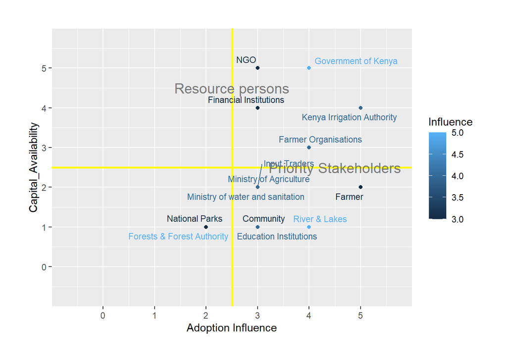

# Project Evaluation

Before investing into the project, pre-calculations to assess the viability of the project is needed. Project installation and setup cost against profits generated over time has to be evaluated.

Rain fed irrigation in Kenya follow a simple evaluation process which is rarely undertaken by the farmers.

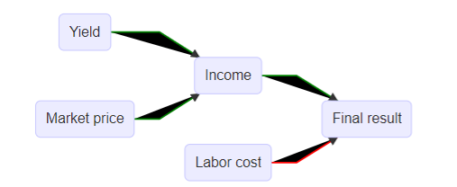

# Conceptual model

This Framework illustrates the contributions and effects of all the uncertainties, assumptions, benefits and negative consequences resulting from the project while considering both short and long term benefits and general cost for the project.

At Policy Level - The government is faced with a duty to decide on the best public good to invest in which should be economically viable. Currently the government employs the surface system of irrigation and we want them to adopt the new Drip Irrigation technologies because of the benefits.Government always looks at the social economic value and the viability of the project before making decision to adopt and allocate resources.

Drip Irrigation Option

Benefits Considering the option of Drip Irrigation, benefits were categorized depending on the period they would be achieved. Short-term (ie. the benefits that are immediately realized a few months (6-12 months) after the installation of the technology) for example; Increase in yields, enhanced water use efficiency, reduction in farmer operational costs as hired labor gets low and reduced weeding intervals thus increasing farmer savings. These were mainly Benefits to Farmers (BFT). The other category is Long-term (ie. benefits achieved above one year, these are basically benefits to both the government and farmers (BTGF) these include; increase in incomes and standards of living, better nutrition, increase in Hydro Power generation ( a big earner to government) as a result of reduction in water diversion from the Pekera and Nyamindi rivers into the scheme, enhancement in tourism due to enhanced water management in the landscape to support biodiversity and National Parks (Mwea National Reserve), and lastly improvement in Landscape and Ecosystem.

The Total Benefits (TB) from the option of Drip Irrigation is considered as a function of the Benefits from Short-term and benefits from Long-term.

The costs resulting from this option were also assessed (Installation and Maintenance costs) to get the Total Costs of the project.

# Assumptions

Definitely to realize the results of the project there are certain factors that have to be put into consideration so have to increase the project’s success these include;

1. Good Agronomy- This should hold if the project is to realize the increase in yields
2. Climate Change (external factor) - this should be considered through assessing of the readily available global data to prepare adequately for the changing weather patterns. In the recent past Kenya as experienced drought making such investments for the public good justifiable.

3.Technical Knowledge - to properly make use of the technology to maximize the outcome

4. High Value crops - To offset the investment cost, the technology has to be applied on high income crops which are water intensive.
5. Markets grow - to ensure high incomes and improved living standards to farmers, the market institutions should be stable and growing.
6. Co-partners - such an investment is costly. This constrains the allocation of huge sums of money to single projects. Availability of institutions like Banks for credit or donors increases the chances of the project uptake.
7. Corruption - from past news-casts and real-life experiences it is known that many of the government investments are failed due to ballooned budgets. For this project to be taken on the government has to limit the occurrence of this vice.
8. The farmers are users of the technology should handle it with great care to lower the maintenance cost.

Surface Irrigation Option

In order to assess the benefits of the Drip Irrigation, a comparison from the statusquo technique (Surface Irrigation) using the same inputs of Yields, Water usage, incomes, Hydo-Power generation, earning from tourism ( abundance of biodiversity), Ecosystem, Nutrition and savings from labor and weeding) was done to get the actual benefits from this option. Installation and Maintenance costs were also looked for easy comparisons.

Decision Uptake Analysis

This is based on the Net decision Outcome from either option considering the factors of Net Present Value (NPV). We know that the climate is changing and so are the precipitation events, we factored in the Drought scenario to assess the results of both options both in normal years and drought years.These will form our basic parts of Monte Carlo Evaluation process.

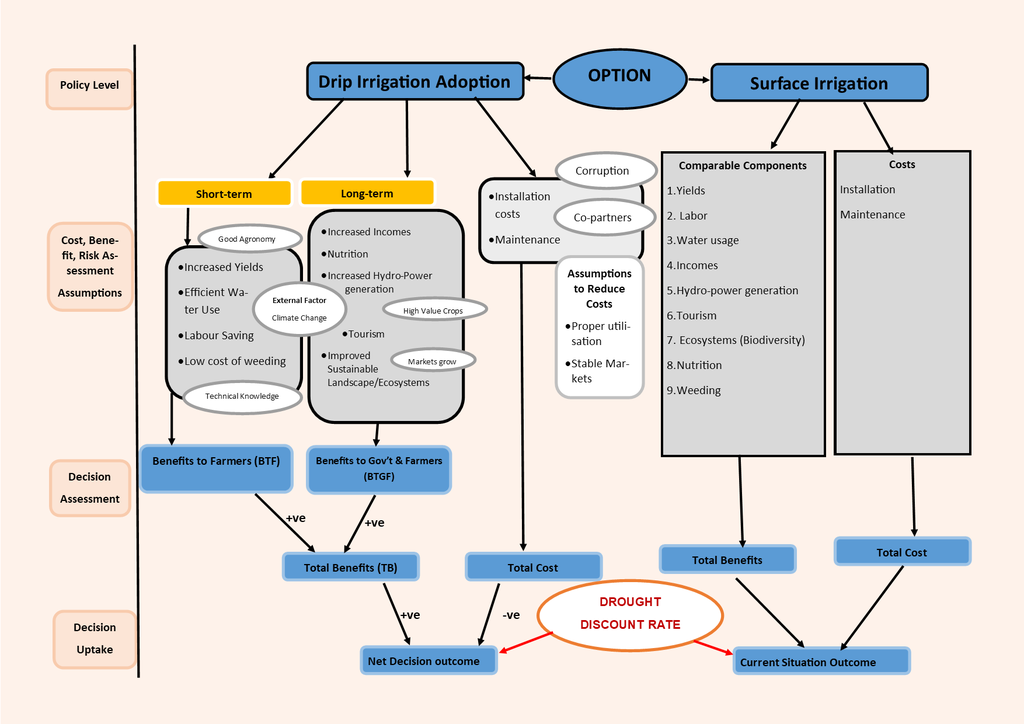

## Impact pathways for the Various Options

This is a graphical representation of the path and general flow of the evaluation of the project model.

### Drip Irrigation Impact Pathway

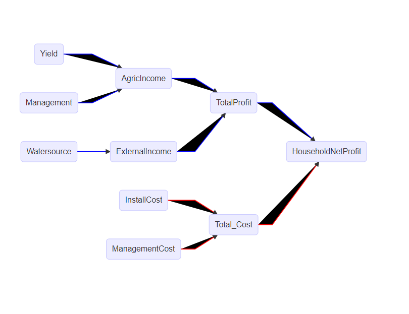

### Surface Irrigation Impact Pathway

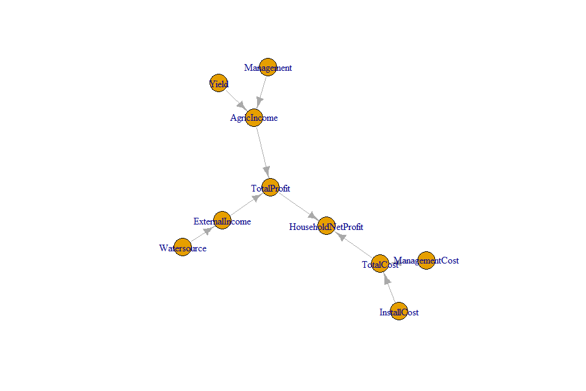

## Estimates

During the calibration training, the authors gained skills in providing expert estimates on the various required variables from the conceptual model.These were provided based on literature, gut feeling, individual experiences and verification with the author who comes from the Kenya.

Apart from yields as inputs in the estimates (tonnes/hectare) which we later monetized with the market price (5.00 KSh), the other estimates were put as 1,000 of Kenyan Shillings (KSh.). To have a shortened table of estimates, the inputs from the conceptual model were summarized into 3 broad variables for each option as follows;

Drip Irrigation option variables 1. Drip_Yields = ton/ha of maize 2. Drip_management = all savings due to the technology (labor & weeding) 3. Drip_All_other_incomes = all savings due to the technology (labor & weeding) (incomes, nutrition, power generation, ecosystem) 4. Drip_Establishmentcost = the cost due to the installation of the technology 5. Drip_MaintenanceCost = All expenses that accrue due to the maintenance of the project

Surface Irrigation option variables 1. Surface_Yields = ton/ha of maize 2. Surface_Management = all savings due to the technology (labor & weeding) 3. Surface_All_other_incomes = all savings due to the technology (labor & weeding) (incomes, nutrition, power generation, ecosystem) 4. Surface_Establishmentcost = the cost due to the installation of the technology 5. Surface_MaintenanceCost = All expenses that accrue due to the maintenance of the project

To be able to evaluate the Net Present Value of all the decision option, we used the Discount rate of 8.0% (lower) and 12.0% (upper) which is widely recommended by the World Bank and International Development Cooperation as a standard for evaluating public investments in Developing Countries.

Due to the certainty in the area of study about the prevalence of drought, we also considered the drought estimates in the table to be around 10.0% (lower) and 20.0% (upper)

The all project is assessed for a period of 5 years. This is based on the period we consider the drip irrigation option to have fully recovered the investment.

| variable | lower | median | upper | distribution | label | Description | X | X.1 | X.2 |
| --- | --- | --- | --- | --- | --- | --- | --- | --- | --- |
| Drip_Yield | 25.0 |  | 50.0 | posnorm | Yield (t/ha) | Amount from the Yield of the maize crop |  |  |  |
| Drip_Management | 10.0 |  | 39.0 | posnorm | management_savings(ksh) | Amount saved on labour and weed management |  |  |  |
| Drip_All_other_incomes | 14.0 |  | 50.0 | posnorm | All other earnings(ksh) | "Amount earned and saved from all other inputs (Tourism | Electricity | Taxes | ESS among others) efficient water use from basin" |
| Drip_Establishmentcost | 18.0 |  | 81.0 | posnorm | Instalationcost(ksh) | Cost of installing the project |  |  |  |
| Drip_MaintenanceCost | 8.0 |  | 34.0 | posnorm | Maintenance cost(Ksh) | Cost of project maintainance |  |  |  |
| Surface_Yield | 14.0 |  | 40.0 | posnorm | Yield (Ksh/ha) | Amount from the Yield of the maize crop |  |  |  |
| Surface_Management | 2.0 |  | 10.0 | posnorm | management_savings(ksh) | Amount saved on labour and weed management |  |  |  |
| Surface_All_other_incomes | 10.0 |  | 23.0 | posnorm | All other earnings(ksh) | Amount earned and saved from all other inputs (Tourism, Electricity,Taxes, ESS among others)efficient water use from basin |  |  |  |
| Surface_Establishmentcost | 10.0 |  | 20.0 | posnorm | Installationcost(ksh) | Cost of installing the project |  |  |  |
| Surface_MaintenanceCost | 4.0 |  | 10.0 | posnorm | Maintenance cost(Ksh) | Cost of project maintainance |  |  |  |
| Marketvalue | 5.0 |  | 5.0 | const | Price (ksh/t) | Market price per KG of maize grain |  |  |  |
| discount_rate | 8.0 |  | 12.0 | posnorm |  | Discount rate (%) |  |  |  |
| Drought_Event | 0.1 |  | 0.3 | tnorm_0_1 |  | Risk of drought |  |  |  |
| Drought_Discount | 0.1 |  | 0.2 | posnorm |  | losses due to drought |  |  |  |
| Var_CV | 5.0 |  | 20.0 | posnorm |  | coeff. Variation |  |  |  |
| n_years | 5.0 |  | 5.0 | const |  | Project time horizon (years) |  |  |  |

# Simple model code

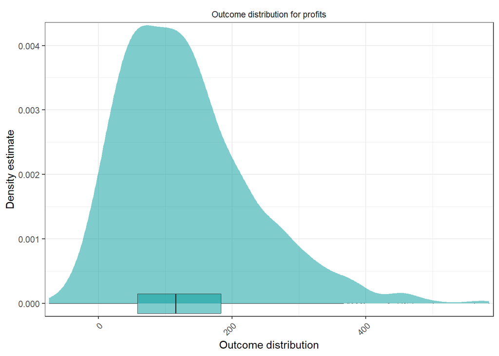

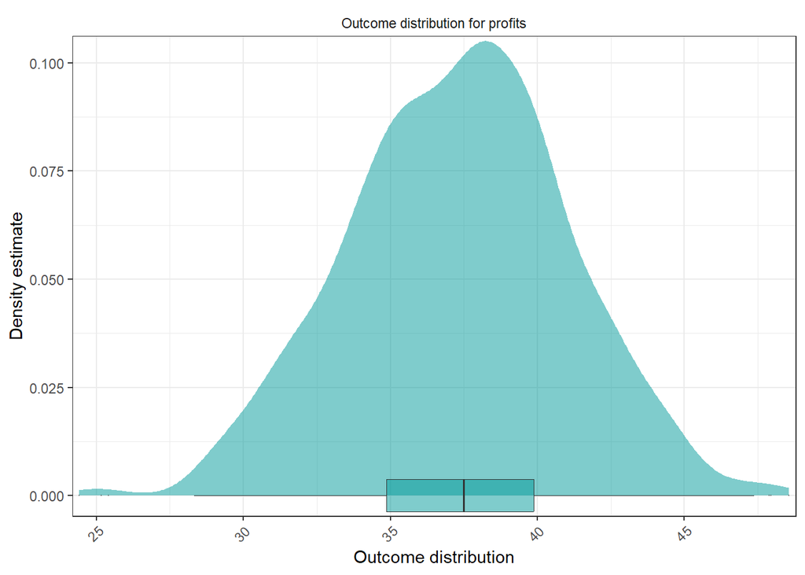

## Analysis of the Results of the simple model

Drip Irrigation. The distribution indicated a lot of uncertainties in the outcomes as it was widely spread out but with a few figures in the negative and majority on the positive side upto 500KSh. (in 1,000Ksh.)

Surface Irrigation. The distribution was evenly spread out with far less outcomes compared to Drip irrigation about 45 KSh (in 1,000 Ksh)

##Shortfalls of the simple model. The simple model was overly simplified because the following important aspects were not considered.

1. The estimates were not being fetched from the same estimate table.
2. Each decision option had its own model function, this limited the mcSimulation results to be subjected to the same environment.
3. Separating the distribution plots doesn’t allow you chance to properly assess the results on how the distributions shade (over rap) each other.
4. It never considered important factors for decision analysis in the context of the Irrigation scheme like; NPV, Discount rate, number of years for the assessment, and varying of the installation costs to only run for the first year.

Note: All these shortfalls made the simple model so unrealistic to be used in decision making.

# Model Upgrade

To improve the assessment for a better decision option, we addressed the shortfalls for the simple model by;

1. Joining the estimates to have one csv. table of estimates.
2. Combining both decision options to be run in one code-block
3. The time frame for the project was set to 5 years as the timeline considered to have generated enough income to offset the cost of Drip Irrigation system installation.
4. The Installation costs for both decision options were made to run for only the first year of the project implementation.
5. The distributions were plotted and analysed together for both decision options.
6. We introduced the vv() function from the decisionSupport library because many of our considered variables vary over time. This variation in time series analyses enabled us to have a clear output of the variables considering a desired coefficient of variation of 5.0% (lower) and 20.0% (upper).
7. Also the chance_event() function from the decisionSupport library was introduced that took into account the drought event occurrence with in our simulations. The estimates used were 10.0% (lower) and 30.0% (upper).
8. Better decision assessment functions were introduced to visualize the outcomes for proper analysis to facilitate decision making. These include;
   1. plot_distributions()function from decisionSupport library to show the full results of Monte Carlo model with the expected NPV considering if the government implemented the project or not. The boxplots with median was added to compare the outcomes of both decision options with their outliers.
   2. plot_cashflow() function from decisionSupport library to show the cashflow analysis distribution of the cashflow for the 5 years of the project assessment using the specific cashflows indicted from the mcSimulation() using cashflow_decision_Surface/Drip.
   3. compound_figure() function from the decisionSupport library to show single figure outputs for assessment. This analysis was to help in decision making if to take-up the project or not as well as indicating the most important variables.

## Model without Drought

We wanted to simulate the outcomes of the project under normal conditions (rain) to assess if it is justifiable to invest in the expensive technology. This was achieved with the chance_event() function while setting the value_if to 0, and Value_if_not to 0, for the 5 years of the assessment.

[output not shown]

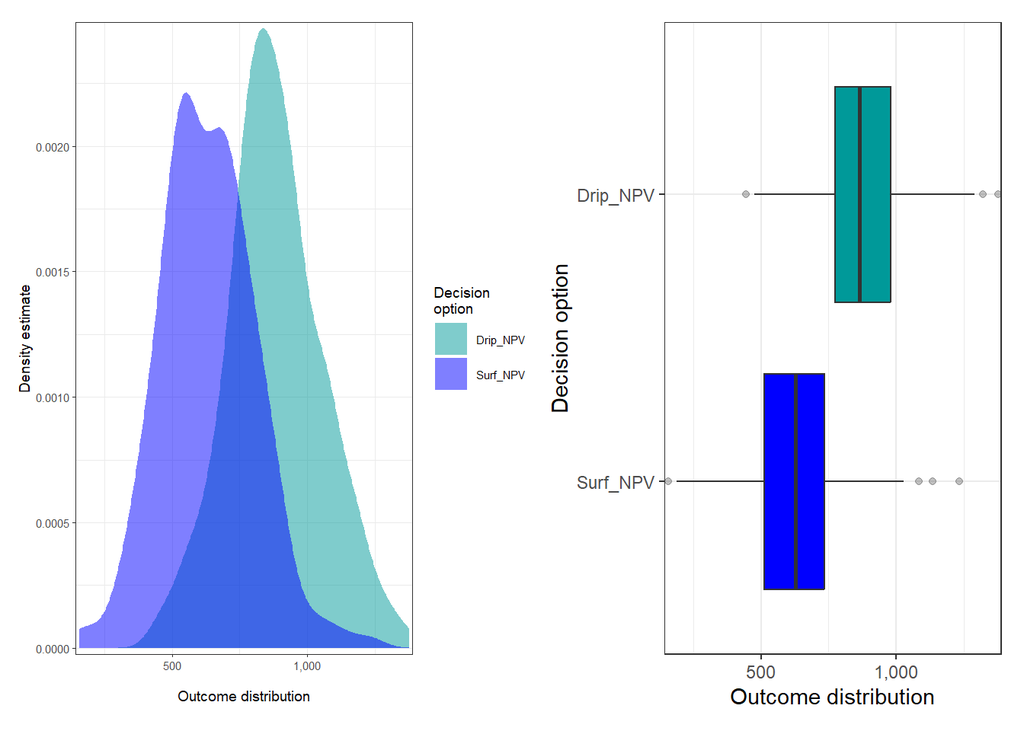

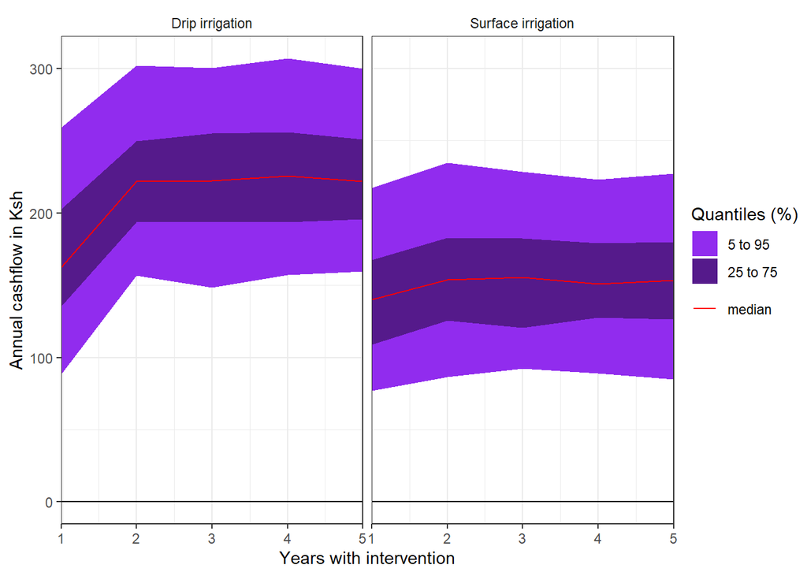

```
## [1] "Processing 1 output variables. This can take some time."
## [1] "Output variable 1 (Drip_NPV) completed."
```

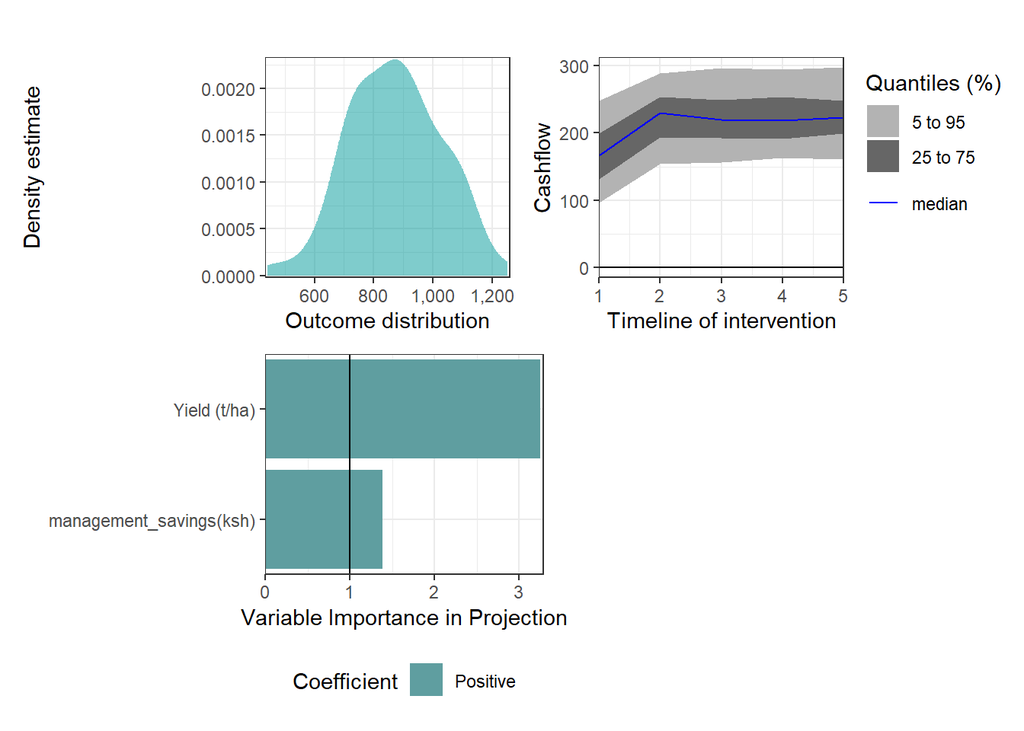

```
## [1] "Processing 1 output variables. This can take some time."
## [1] "Output variable 1 (Surf_NPV) completed."
```

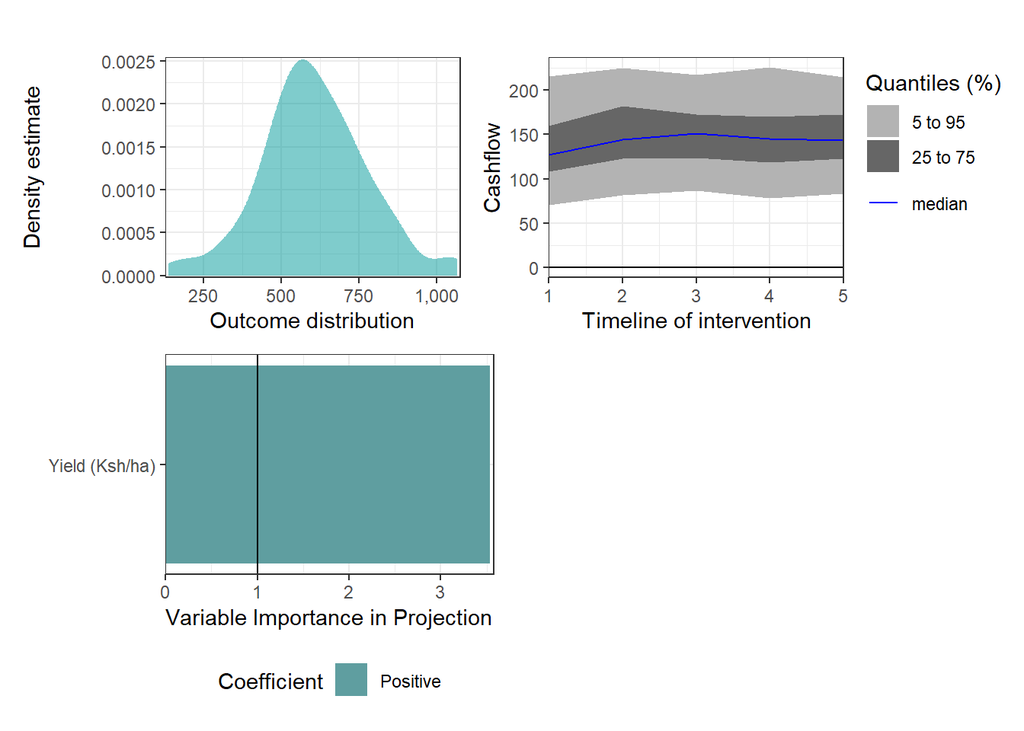

### Analysis of the Results without Drought

#### plot_cashflow() function results

The distributions from the cashflows for the 5 years of the Drip Irrigation decision option assessment had a median outcome rising very fast in the 2 years of the project implementation afterwards, it started varying but far higher than the median of surface Irrigation decision option. The median of the surface Irrigation decision option slightly rose in the first 3 years of implementation and it somehow leveled off during the 5 year period of assessment.

#### compound_figure() function results

To explicitly have a clear understanding of the decision option outcomes, we generated the single figure from all variables.

Drip Irrigation decision option had Yields, All other earnings and management_savings as positive values with All other earnings and Yields variables above the threshold indicating that they are very important inputs to consider in the assessment model. The Installation costs negatively impact the outcomes but it is very important to consider as it has a great value of information to determine the decision option.

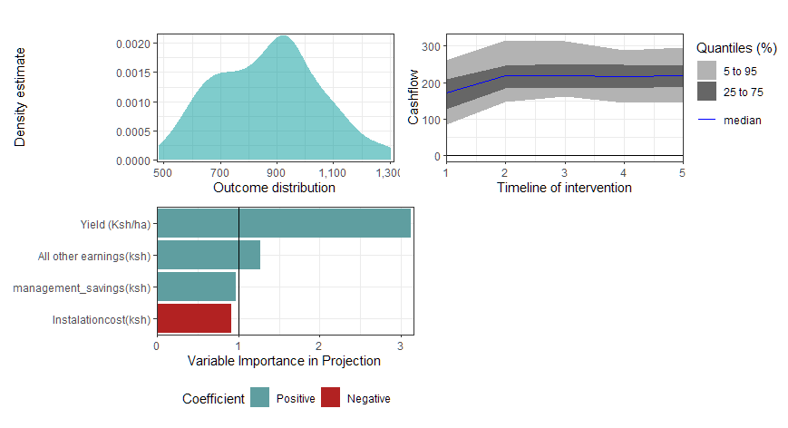

[figure not shown]

## Model with Drought

After assessing the results in normal conditions with no drought, we wanted to see if the project was still profitable in the much anticipated climate change with the occurrence of drought. This was achieved with the chance_event() function while setting the value_if to 1, and Value_if_not to 0, for the 5 years of the assessment.

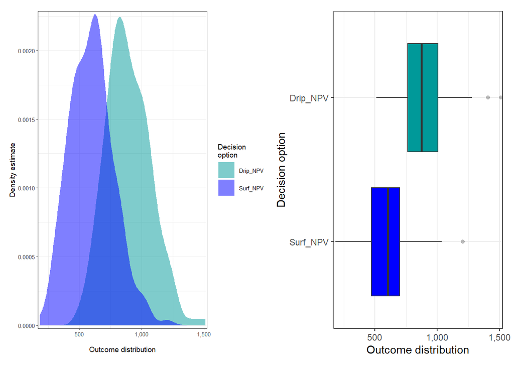

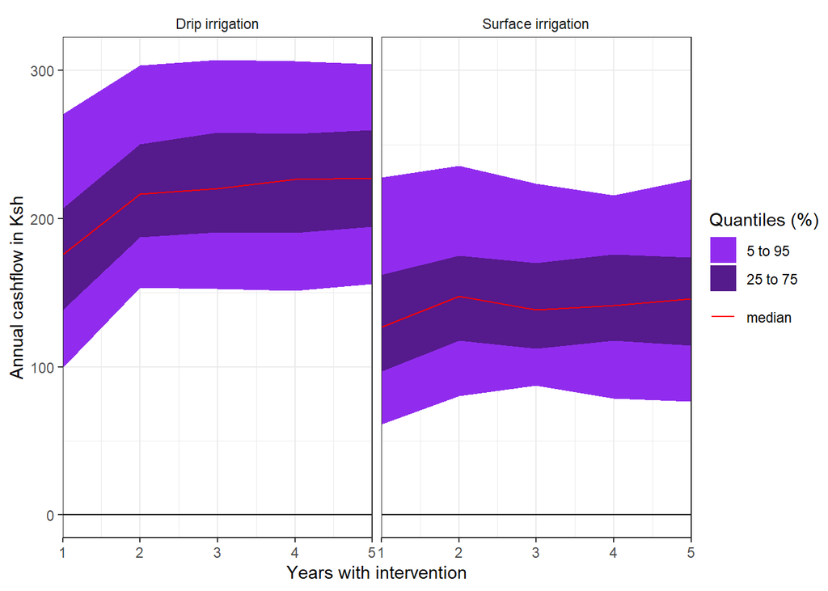

```
## [1] "Processing 1 output variables. This can take some time."
## [1] "Output variable 1 (Drip_NPV) completed."
```

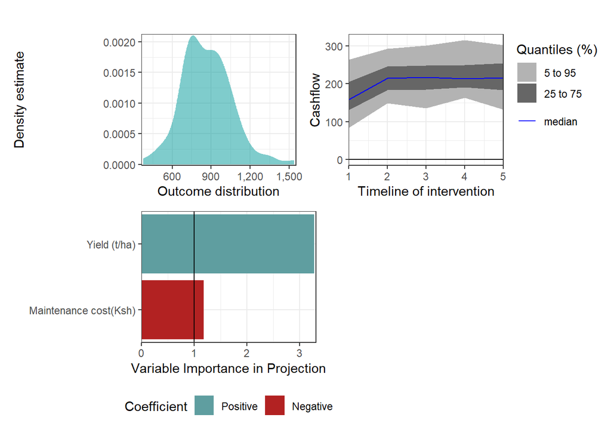

```
## [1] "Processing 1 output variables. This can take some time."
## [1] "Output variable 1 (Surf_NPV) completed."
```

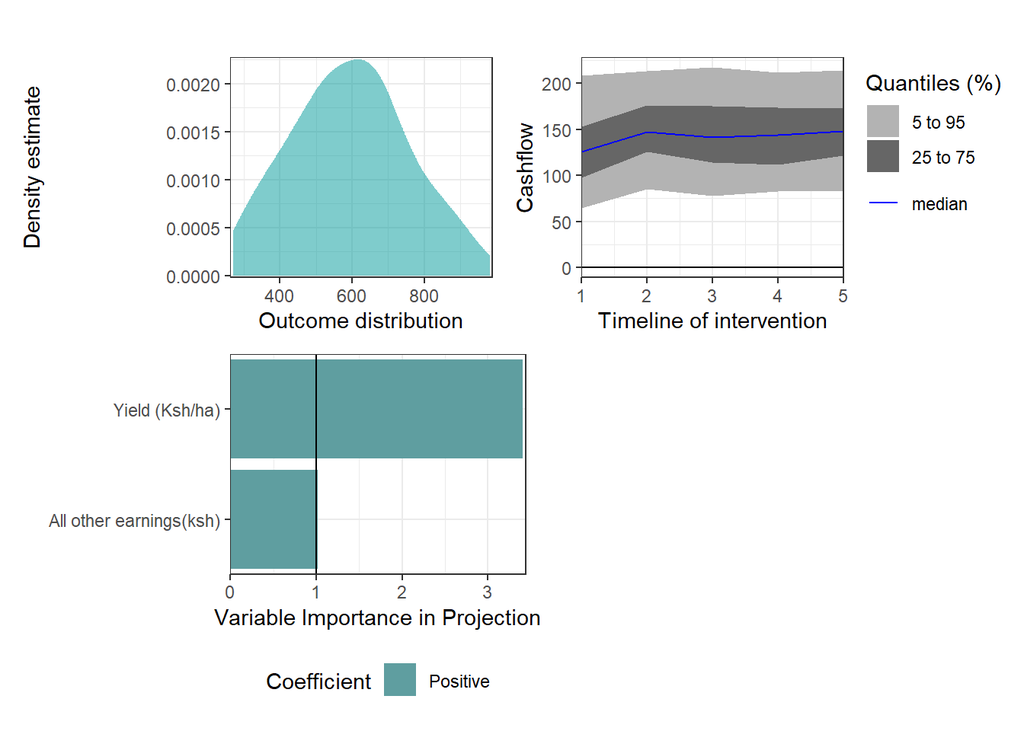

### Analysis of the Results with Drought

#### plot_cashflow() function results

The distributions from the cashflows for the 5 years of the Drip Irrigation decision option assessment had a median outcome rising very fast in the first year of the project implementation afterwards, it started varying but far higher than the median of surface Irrigation decision option. The median of the surface Irrigation decision option slightly rose in the first 2 years of implementation and it somehow leveled off during the 5 year period of assessment.

#### compound_figure() function results

To explicitly have a clear understanding of the decision option outcomes, we generated the single figure from all variables.

# Learning points

```r
# Compound drip irrigation
compound_figure(model = irrigation_model_function_withoutDrought,
                input_table = input_table,
                decision_var_name = "Drip_NPV",
                cashflow_var_name = "Cashflow_decision_drip",
                model_runs = 1e2,
                distribution_method = 'smooth_simple_overlay',
                labels("Drip Irrigation"))
```

```
## [1] "Processing 1 output variables. This can take some time."
## [1] "Output variable 1 (Drip_NPV) completed."
```

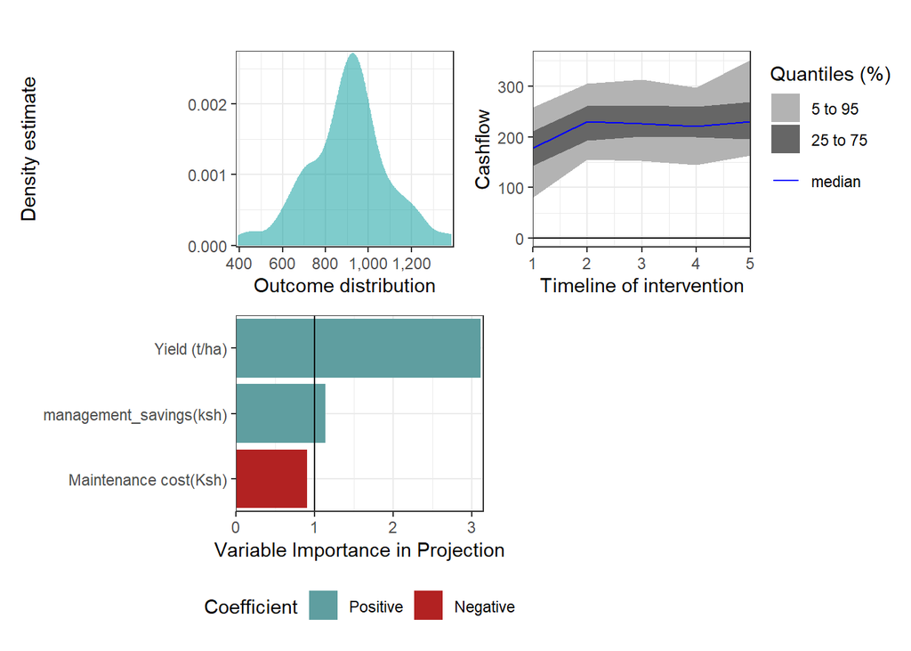

```r
#compound surface irrigation
compound_figure(model = irrigation_model_function_withoutDrought,
                input_table = input_table,
                decision_var_name = "Surf_NPV",
                cashflow_var_name = "Cashflow_decision_surface",
                model_runs = 1e2,
                distribution_method = 'smooth_simple_overlay',
                labels("Surface Irrigation"))
```

```
## [1] "Processing 1 output variables. This can take some time."
## [1] "Output variable 1 (Surf_NPV) completed."
```

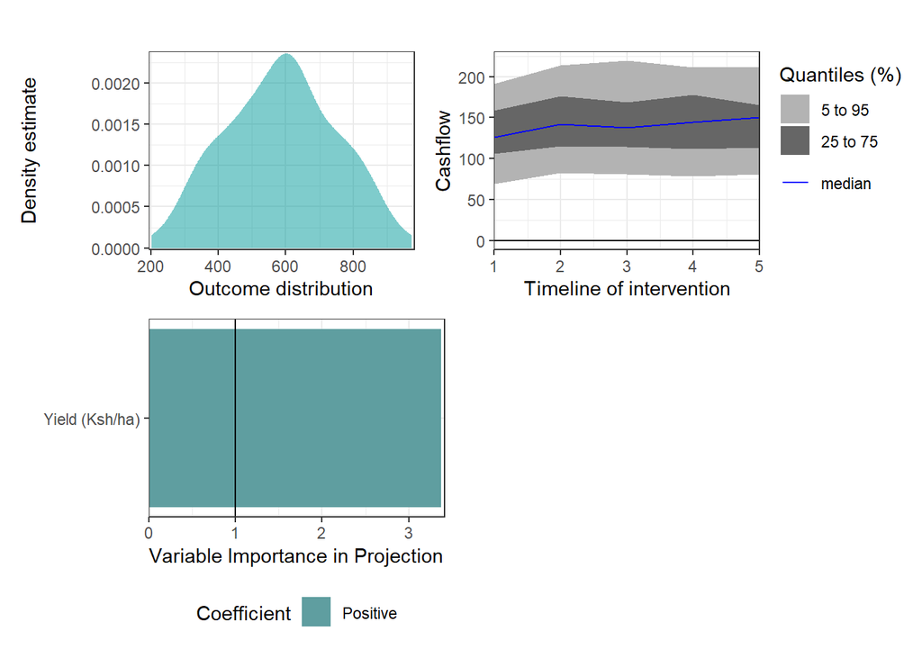